# Practical Machine Learning - Weight Lifting Exercise Prediction

Februar 2016

# Experiment & Task

Six participants were asked to perform one set of 10 repetitions of the Unilateral Dumbbell Biceps Curl in five different fashions:

| Class A | Class B | Class C | Class D | Class E |
| --- | --- | --- | --- | --- |
| exactly according to specification | throwing elbows to the front | lifting the dumbbell only halfway | lowering the dumbbell only halfway | throwing the hips to the front |

The task is to predict the manner in which people did the Unilateral Dumbbell Biceps Curl exercise in a test set using the best fit model, fitted on the “classe” variable of the training set. We shall outline how the model is build, conduct cross-validation of our results and discuss the accuracy of the model.

## Load

First of all, we load the dataset. Since we do not want to download the files on each analysis run we follow a 2-step process. First, if the files have not been downloaded to the local folder we download them. In any subsequent analysis run (such as the analysis at hand) , the files will not be re-downloaded as they are already available in the local folder.

```r
src_train <- read.csv("pml-training.csv")
src_test <- read.csv("pml-testing.csv")
```

## Explore

Here we get a grasp on the overall dataset, its structure and summary statistics.

```r
names(src_train)
```

```
##   [1] "X"                        "user_name"
##   [3] "raw_timestamp_part_1"     "raw_timestamp_part_2"
##   [5] "cvtd_timestamp"           "new_window"
##   [7] "num_window"               "roll_belt"
##   [9] "pitch_belt"               "yaw_belt"
##  [11] "total_accel_belt"         "kurtosis_roll_belt"
##  [13] "kurtosis_picth_belt"      "kurtosis_yaw_belt"
##  [15] "skewness_roll_belt"       "skewness_roll_belt.1"
##  [17] "skewness_yaw_belt"        "max_roll_belt"
##  [19] "max_picth_belt"           "max_yaw_belt"
##  [21] "min_roll_belt"            "min_pitch_belt"
##  [23] "min_yaw_belt"             "amplitude_roll_belt"
##  [25] "amplitude_pitch_belt"     "amplitude_yaw_belt"
##  [27] "var_total_accel_belt"     "avg_roll_belt"
##  [29] "stddev_roll_belt"         "var_roll_belt"
```

[output cut: 65 more lines]

```r
dim(src_train)
```

```
## [1] 19622   160
```

```r
summary(src_train)
```

```
##        X            user_name    raw_timestamp_part_1 raw_timestamp_part_2
##  Min.   :    1   adelmo  :3892   Min.   :1.322e+09    Min.   :   294
##  1st Qu.: 4906   carlitos:3112   1st Qu.:1.323e+09    1st Qu.:252912
##  Median : 9812   charles :3536   Median :1.323e+09    Median :496380
##  Mean   : 9812   eurico  :3070   Mean   :1.323e+09    Mean   :500656
##  3rd Qu.:14717   jeremy  :3402   3rd Qu.:1.323e+09    3rd Qu.:751891
##  Max.   :19622   pedro   :2610   Max.   :1.323e+09    Max.   :998801
##
##           cvtd_timestamp  new_window    num_window      roll_belt
##  28/11/2011 14:14: 1498   no :19216   Min.   :  1.0   Min.   :-28.90
##  05/12/2011 11:24: 1497   yes:  406   1st Qu.:222.0   1st Qu.:  1.10
##  30/11/2011 17:11: 1440               Median :424.0   Median :113.00
##  05/12/2011 11:25: 1425               Mean   :430.6   Mean   : 64.41
##  02/12/2011 14:57: 1380               3rd Qu.:644.0   3rd Qu.:123.00
##  02/12/2011 13:34: 1375               Max.   :864.0   Max.   :162.00
##  (Other)         :11007
##    pitch_belt          yaw_belt       total_accel_belt kurtosis_roll_belt
##  Min.   :-55.8000   Min.   :-180.00   Min.   : 0.00             :19216
##  1st Qu.:  1.7600   1st Qu.: -88.30   1st Qu.: 3.00    #DIV/0!  :   10
##  Median :  5.2800   Median : -13.00   Median :17.00    -1.908453:    2
##  Mean   :  0.3053   Mean   : -11.21   Mean   :11.31    -0.016850:    1
##  3rd Qu.: 14.9000   3rd Qu.:  12.90   3rd Qu.:18.00    -0.021024:    1
##  Max.   : 60.3000   Max.   : 179.00   Max.   :29.00    -0.025513:    1
##                                                        (Other)  :  391
##  kurtosis_picth_belt kurtosis_yaw_belt skewness_roll_belt
##           :19216            :19216              :19216
##  #DIV/0!  :   32     #DIV/0!:  406     #DIV/0!  :    9
##  47.000000:    4                       0.000000 :    4
##  -0.150950:    3                       0.422463 :    2
##  -0.684748:    3                       -0.003095:    1
##  -1.750749:    3                       -0.010002:    1
##  (Other)  :  361                       (Other)  :  389
##  skewness_roll_belt.1 skewness_yaw_belt max_roll_belt     max_picth_belt
##           :19216             :19216     Min.   :-94.300   Min.   : 3.00
##  #DIV/0!  :   32      #DIV/0!:  406     1st Qu.:-88.000   1st Qu.: 5.00
##  0.000000 :    4                        Median : -5.100   Median :18.00
##  -2.156553:    3                        Mean   : -6.667   Mean   :12.92
##  -3.072669:    3                        3rd Qu.: 18.500   3rd Qu.:19.00
##  -6.324555:    3                        Max.   :180.000   Max.   :30.00
##  (Other)  :  361                        NA's   :19216     NA's   :19216
```

[output cut: 313 more lines]

```
##  Min.   :-446.00   Min.   :-1280.0   Min.   :-896.0   Min.   :-973.0
##  1st Qu.:-182.00   1st Qu.: -616.0   1st Qu.:   2.0   1st Qu.: 191.0
##  Median : -39.00   Median : -378.0   Median : 591.0   Median : 511.0
##  Mean   : -55.29   Mean   : -312.6   Mean   : 380.1   Mean   : 393.6
##  3rd Qu.:  26.00   3rd Qu.:  -73.0   3rd Qu.: 737.0   3rd Qu.: 653.0
##  Max.   : 291.00   Max.   :  672.0   Max.   :1480.0   Max.   :1090.0
##
##  classe
##  A:5580
##  B:3797
##  C:3422
##  D:3216
##  E:3607
##
##
```

Due to the big amount of 160 variables included, we decide against further exploratory analysis to detect correlation structures using featureplot e.g. but will directly step into preparation of machine learning model fits in the next steps.

## Clean

Now we turn to cleaning the data from:

1. Irrelevant Variables
2. Near Zero Variance Variables
3. Variables with too many N/A values

### Remove Irrelevant

Looking at the variables we do not expect that neither the running ID variable **X**, the **user_name** nor any of the timestamp variables have a significant influence on the outcome variable **classe** unless the experiment setup is flawed itself.

```r
clean_irrelevant <- c("X","user_name","raw_timestamp_part_1","raw_timestamp_part_2","cvtd_timestamp")
clean_names <- names(src_train) %in% clean_irrelevant
src_train_cleaned <- src_train[!clean_names]
src_test_cleaned <- src_test[!clean_names]
dim(src_train_cleaned)
```

```
## [1] 19622   155
```

```r
dim(src_test_cleaned)
```

```
## [1]  20 155
```

The Training and Test data sets were shrinked by 5 variables.

### Remove N/As

Now we set up an algorithm to either impute or remove variables with too many n/a values. The summary table revealed that some columns either have no n/a values or a large amount. Hence we decide to remove all columns that contain more than 30% n/a values:

```r
totRows <- nrow(src_train_cleaned);
naFraction <- 0.3;
totNaFraction <- naFraction * totRows;
stc <- src_train_cleaned;
src_train_cleaned <- src_train_cleaned[, colSums(is.na(stc)) < totNaFraction];
src_test_cleaned <- src_test_cleaned[, colSums(is.na(stc)) < totNaFraction];
dim(src_train_cleaned)
```

```
## [1] 19622    88
```

```r
dim(src_test_cleaned)
```

```
## [1] 20 88
```

The Training and Test data sets were shrinked by further 67 variables.

### Remove Near Zero Variance

Variables that have near zero variance are also removed.

```r
clean_nzv <- nearZeroVar(src_train_cleaned, saveMetrics=TRUE)
src_train_cleaned <- src_train_cleaned[!clean_nzv$nzv]
src_test_cleaned <- src_test_cleaned[!clean_nzv$nzv]
dim(src_train_cleaned)
```

```
## [1] 19622    54
```

```r
dim(src_test_cleaned)
```

```
## [1] 20 54
```

The Training and Test data sets were shrinked by further 34 variables.

## Partition

In order to train multiple models we further partition the training test set into a 70% training and 30% validation set such that we arrive at **train**, a **validation** and a **test** data subset.

```r
partThreshold <- 0.7;
inTrain <- createDataPartition(y=src_train_cleaned$classe, p=partThreshold, list=FALSE);
train <- src_train_cleaned[inTrain,];
valid <- src_train_cleaned[-inTrain,];
test <- src_test_cleaned;
dim(train);
```

```
## [1] 13737    54
```

```r
dim(valid);
```

```
## [1] 5885   54
```

```r
dim(test);
```

```
## [1] 20 54
```

```r
#names(train);
#names(test);
```

## Check

Now we perform some basic sanity check on the data sets, i.e.:

1. Does the column number match in all data subsets?

```r
match_cols <- all.equal(ncol(train), ncol(valid), ncol(test));
match_cols
```

```
## [1] TRUE
```

## Fit

Using the **train** data we will now fit **2** different models, a decision tree and a random forest based model.

### Decision Tree

We are now applying the rpart model fit on our cleaned train data set and creating the corresponding fancyRpart plot to visualize the result decision tree.

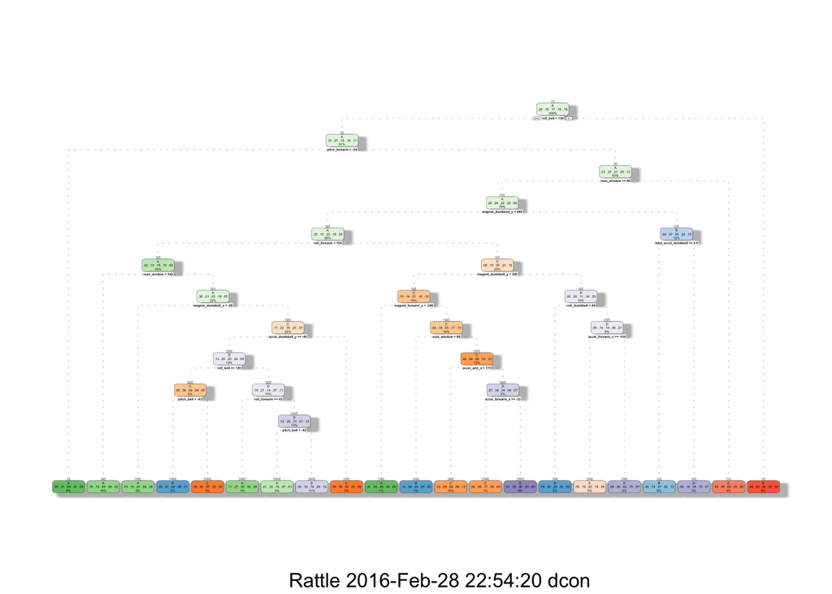

```r
modFit1 <- rpart(classe ~ ., data=train)
fancyRpartPlot(modFit1)
```

We can now use the result decision tree to predict **classe** based on **modFit1**:

```r
pred1 <- predict(modFit1, newdata=valid, type="class")
```

### Random Forest

Now we run the same analysis using a random forest algorithm:

```r
modFit2 <- randomForest(classe ~ ., data=train)
pred2 <- predict(modFit2, newdata=valid, type="class")
```

## Analyse

Looking at the **confusionMatrix accuracy** we would favor the random forest algorithm over the decision tree based approach:

```r
confusionMatrix(pred1, valid$classe)
```

```
## Confusion Matrix and Statistics
##
##           Reference
## Prediction    A    B    C    D    E
##          A 1530  269   51   79   16
##          B   35  575   31   25   68
##          C   17   73  743   68   84
##          D   39  146  130  702  128
##          E   53   76   71   90  786
##
## Overall Statistics
##
##                Accuracy : 0.7368
##                  95% CI : (0.7253, 0.748)
##     No Information Rate : 0.2845
##     P-Value [Acc > NIR] : < 2.2e-16
##
##                   Kappa : 0.6656
##  Mcnemar's Test P-Value : < 2.2e-16
##
## Statistics by Class:
##
##                      Class: A Class: B Class: C Class: D Class: E
## Sensitivity            0.9140  0.50483   0.7242   0.7282   0.7264
## Specificity            0.9014  0.96650   0.9502   0.9100   0.9396
## Pos Pred Value         0.7866  0.78338   0.7543   0.6131   0.7305
## Neg Pred Value         0.9635  0.89051   0.9422   0.9447   0.9384
## Prevalence             0.2845  0.19354   0.1743   0.1638   0.1839
## Detection Rate         0.2600  0.09771   0.1263   0.1193   0.1336
## Detection Prevalence   0.3305  0.12472   0.1674   0.1946   0.1828
## Balanced Accuracy      0.9077  0.73566   0.8372   0.8191   0.8330
```

```r
confusionMatrix(pred2, valid$classe)
```

```
## Confusion Matrix and Statistics
##
##           Reference
## Prediction    A    B    C    D    E
##          A 1674    5    0    0    0
##          B    0 1133    8    0    0
##          C    0    1 1018   12    0
##          D    0    0    0  952    4
##          E    0    0    0    0 1078
##
## Overall Statistics
##
##                Accuracy : 0.9949
##                  95% CI : (0.9927, 0.9966)
##     No Information Rate : 0.2845
##     P-Value [Acc > NIR] : < 2.2e-16
##
##                   Kappa : 0.9936
##  Mcnemar's Test P-Value : NA
##
## Statistics by Class:
##
##                      Class: A Class: B Class: C Class: D Class: E
## Sensitivity            1.0000   0.9947   0.9922   0.9876   0.9963
## Specificity            0.9988   0.9983   0.9973   0.9992   1.0000
## Pos Pred Value         0.9970   0.9930   0.9874   0.9958   1.0000
## Neg Pred Value         1.0000   0.9987   0.9984   0.9976   0.9992
## Prevalence             0.2845   0.1935   0.1743   0.1638   0.1839
## Detection Rate         0.2845   0.1925   0.1730   0.1618   0.1832
## Detection Prevalence   0.2853   0.1939   0.1752   0.1624   0.1832
## Balanced Accuracy      0.9994   0.9965   0.9948   0.9934   0.9982
```

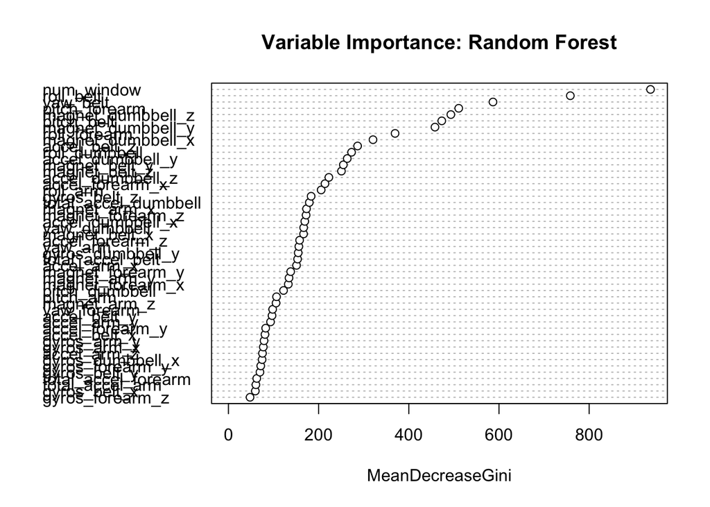

```r
varImpPlot(modFit2, main="Variable Importance: Random Forest", n.var = 50)
```

The Variable Importance Chart also underlines that the random model at hand explains a considerable amount of variance with about 50 variables included.

# Prediction Results

```r
testPred <- predict(modFit2, test, type="class")
testPred
```

```
##  1  2  3  4  5  6  7  8  9 10 11 12 13 14 15 16 17 18 19 20
##  B  A  B  A  A  E  D  B  A  A  B  C  B  A  E  E  A  B  B  B
## Levels: A B C D E
```